# 統計学2

課題2の解答例

矢内 勇生

2018-05-08

# 課題 (1)

## (1)-1

**問題：** 1から6までの目がある「正しい」サイコロを2個振るという作業を1,000回繰り返し、出た目の合計が9になる回数を数えてみよう。

サイコロを用意する。

```r
die <- 1:6
```

### 解答例 I

die1 と die2 という2つのサイコロを別々に振り、それぞれの$i$ ($i = 1, 2, \dots, 1000$) 回目同士を足せばよい。

```r
die1 <- sample(die, size = 1000, replace = TRUE)
die2 <- sample(die, size = 1000, replace = TRUE)
dice <- die1 + die2
```

これで、dice[i] には die1[i] + die2[i] の値が入っている。最初の5つの値で確かめてみよう。

```r
die1[1:5]
```

```
## [1] 1 4 5 6 3
```

```r
die2[1:5]
```

```
## [1] 2 5 6 6 6
```

```r
dice[1:5]
```

```
## [1]  3  9 11 12  9
```

- dice[1] = die1[1] + die2[1]
- dice[2] = die1[2] + die2[2]
- dice[3] = die1[3] + die2[3]
- dice[4] = die1[4] + die2[4]
- dice[5] = die1[5] + die2[5]

となっていることがわかる。

このうち、合計が9になっている回数は、

```r
sum(dice == 9)
```

```
## [1] 106
```

である（乱数生成を行っているので、答えが同じになるとは限らない）。

### 解答例 II

2個サイコロを振るには、

```r
sample(die, size = 2, replace = TRUE)
```

```
## [1] 1 3
```

とすればよい。

2つの値を合計するには、

```r
sum(sample(die, size = 2, replace = TRUE))
```

```
## [1] 7
```

とすればよい。

合計が9かどうか確かめるには、

```r
sum(sample(die, size = 2, replace = TRUE)) == 9
```

```
## [1] FALSE
```

とすればよい。

これを1,000回繰り返し、TRUE の回数を数ればよい。 forループを使って、合計が9のときに count を1つずつ増やすことにすると、以下のようにコマンドが書ける。

```r
count <- 0   # 9の回数を数える。最初は0カウント
for (i in 1:1000) {
  # if条件で、カッコの中身が TRUEのときだけカウントを増やす
  if (sum(sample(die, size = 2, replace = TRUE)) == 9) {
    count <- count + 1  # 条件が満たされたとき、count を元のカウント+1 にする
  }
}
```

合計が9になった回数は、

```r
count
```

```
## [1] 115
```

である。

### 解答例 III

サイコロを2個振り、合計が特定の値xのときにはTRUEを、それ以外の値のときには FALSE を返す関数を作る。

```r
check_dice <- function(x) {
  ## 2つのサイコロの目の合計が x かどうか確かめる関数
  ## 引数： x = 確かめたい合計値
  dice <- sample(1:6, size = 2, replace = TRUE)
  return(sum(dice) == x)
}
```

合計値が9かどうか確かるには、

```r
check_dice(x = 9)
```

```
## [1] FALSE
```

とする。

これを1,000回繰り返すために、`replicate()` 関数を使う。

```r
result <- replicate(n = 1000, check_dice(x = 9))
```

result に TRUE または FALSE が合計で1,000個入っているので、TRUEの個数を数えればよい。

```r
sum(result)
```

```
## [1] 117
```

## (1)-2

**問題：**「正しくない」コイン（表が出る確率が0.5ではないコイン）を500回投げ、表が出た回数を数えよう。表が出る確率は自由に設定してよい（ただし、0, 0.5, 1 を除く）。

表が 0.78の確率で出る（つまり、裏が0.22の確率で出る）コインを500回投げて、表の回数を数える。

```r
unfair <- sample(c("表", "裏"), size = 500, replace = TRUE,
                 prob = c(0.78, 0.22))
sum(unfair == "表")
```

```
## [1] 374
```

500回中374回表が出た。 表の割合は、

```r
sum(unfair == "表") / 500
```

```
## [1] 0.748
```

である。

# 課題 (2)

**問題：** 平均が10, 標準偏差が4の正規分布から乱数を10,000個生成し、結果をヒストグラムにしてみよう。また、乱数の平均値と標準偏差を計算し、元になった分布と比べてみよう。

`rnorm()` 関数を使って平均が10, 標準偏差が4の正規分布から乱数を10,000個生成する。

```r
x <- rnorm(10000, mean = 10, sd = 4)
```

生成した乱数のヒストグラムを描く。

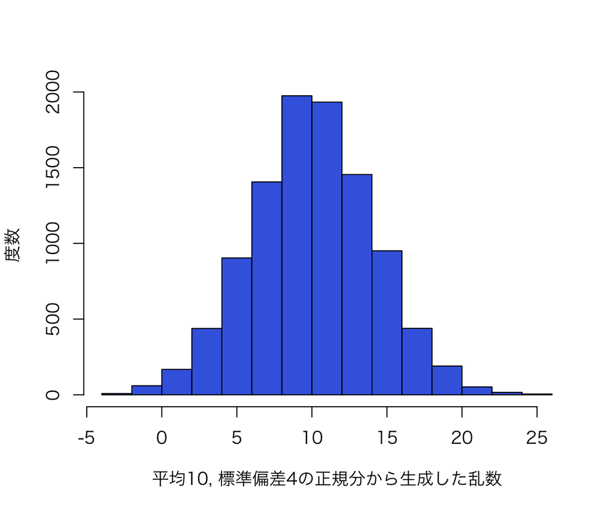

```r
hist(x, col = "royalblue", main = "",
     xlab = "平均10, 標準偏差4の正規分から生成した乱数", ylab = "度数",)
```

平均値は

```r
mean(x)
```

```
## [1] 10.06058
```

で、元の分布の平均値である10に近い。

標準偏差は

```r
sd(x)
```

```
## [1] 4.040348
```

で、これも元の分布の標準偏差である4に近い。

# 課題 (3)

**問題：** 中心極限定理のシミュレーション（このページを参照）を、$n=1$ と $n=500$ で実行しなさい。

## $n=1$ のとき

授業のページにあるコードをそのまま使い、$n$ の値だけ変えて実行すればよい。

```r
bag <- 0:9       # 実験に使う袋の中身を定義する
n <- 1           # サンプルサイズ
trials <- 1000   # 実験の繰り返し回数
sim_n1 <- rep(NA, length = trials)   # 結果の保存容器
for (i in 1:trials) {
  experiment <- sample(bag, size = n, replace = TRUE)  # 復元抽出
  sim_n1[i] <- mean(experiment)  # i 回目の平均値を保存
}
```

ヒストグラムを描いてみよう。

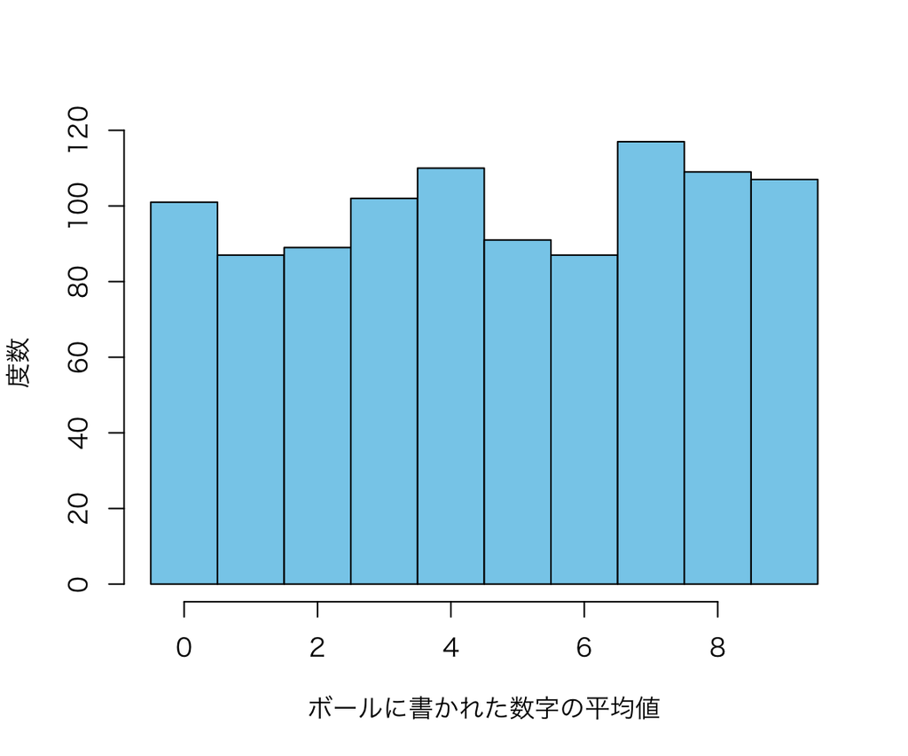

```r
hist(sim_n1, breaks = seq(from = -0.5, to = 9.5, by = 1), col = "skyblue",
     main = "", xlab = "ボールに書かれた数字の平均値", ylab = "度数")
```

$n=1$のとき、平均値の分布はまったく正規分布に似ていない。元々の一様分布のままである。

## $n=500$ のとき

標本サイズ $n$ を500に増やして同じシミュレーションをしてみよう。

```r
n <- 500         # サンプルサイズ
sim_n500 <- rep(NA, length = trials)   # 結果の保存容器
for (i in 1:trials) {
  experiment <- sample(bag, size = n, replace = TRUE)  # 復元抽出
  sim_n500[i] <- mean(experiment)  # i 回目の平均値を保存
}
```

ヒストグラムを描いてみよう。

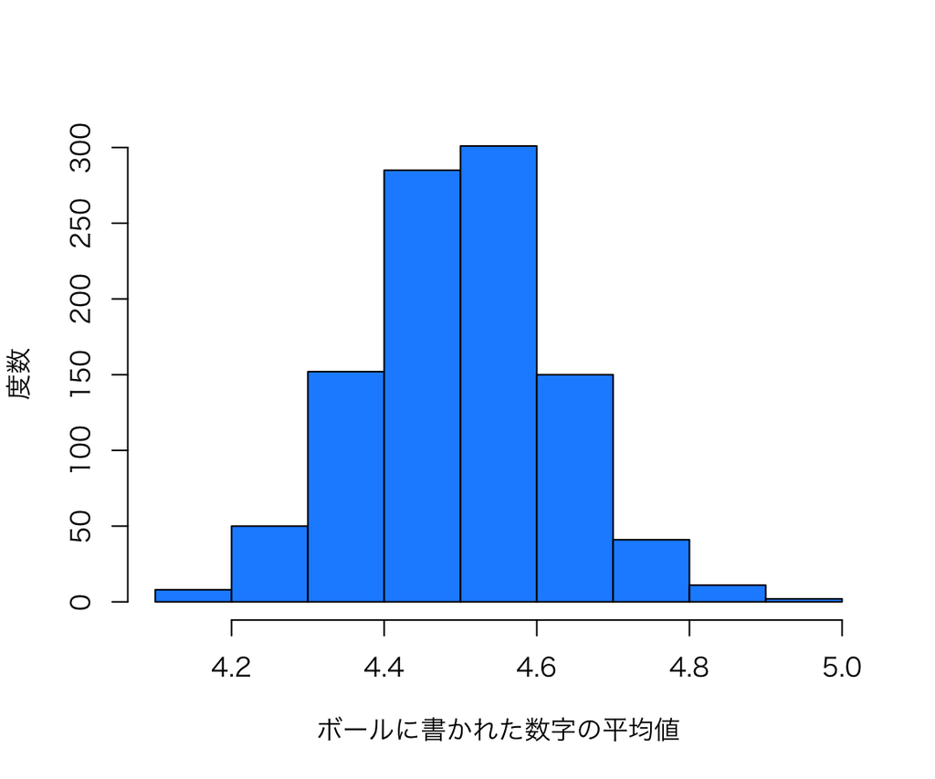

```r
hist(sim_n500, col = "dodgerblue",
     main = "", xlab = "ボールに書かれた数字の平均値", ylab = "度数")
```

$n$ が大きくなると、平均値の分布が正規分布に近づくことがわかる。

授業の内容に戻る